# Solution: Competitive lotka-volterra: fitting several time series at once

Camille Saade

17/05/2022

In this script, we fit a single model over all replicates. To illustrate the use of random effect, we’ll assume that the growth rates $r_1$ and $r_2$ vary between replicates, but that that they are all drawn from the same distribution. Biologically, this could be the case if each replicate is a bloc of experiment done at different times of the year so that temperature and lighting might change a bit in the lab.

# I - Data importation

```r
# cleaning the env:
rm(list = ls())
# loading libraries:
library(rstan) #  for the stats
```

```r
library(ggplot2) # for some plots
library(coda) # diagnostic of mcmc output
library(deSolve) # to integrate ODEs
```

```r
## importing data
data = read.csv('Data/competiton_multi.csv')
head(data)
```

```
##   X      time        n1        n2 replicate   species
## 1 1  0.000000  2.742681  18.58605         1 coculture
## 2 2  6.896552  2.635985  33.98916         1 coculture
## 3 3 13.793103  6.009422  60.65547         1 coculture
## 4 4 20.689655  8.542415  92.95985         1 coculture
## 5 5 27.586207 12.499755 130.50128         1 coculture
## 6 6 34.482759 17.496516 159.95392         1 coculture
```

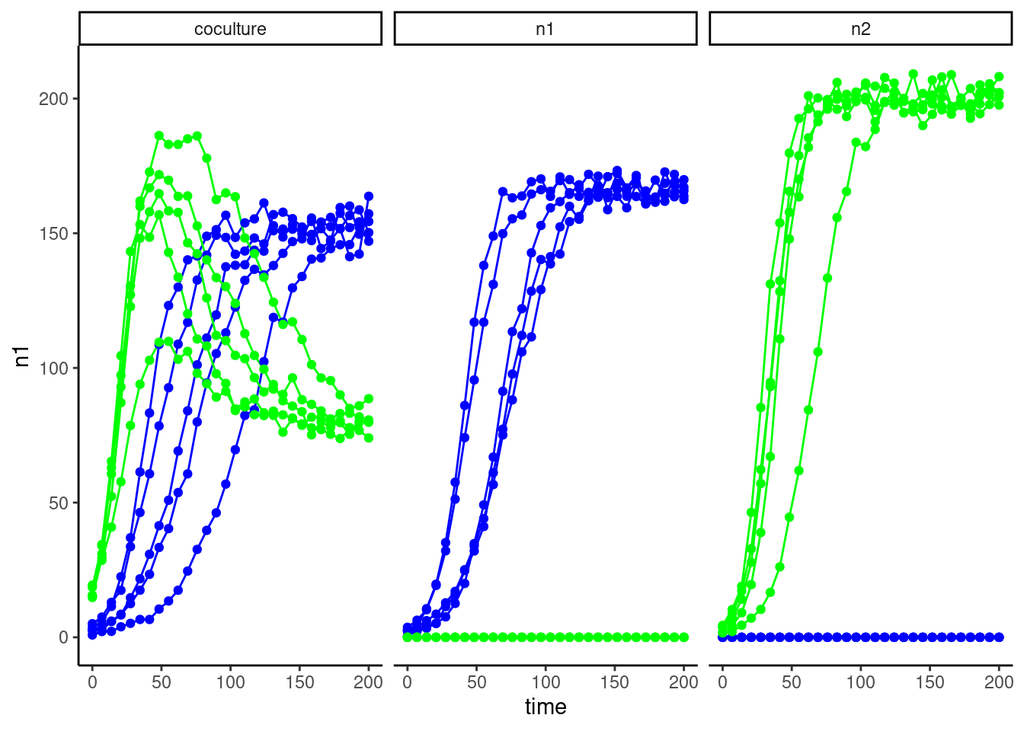

```r
ggplot(data = data) +
  geom_line(mapping = aes(x = time, y = n1, group = replicate), color = 'blue') +
  geom_line(mapping = aes(x = time, y = n2, group = replicate), color = 'green') +
  geom_point(mapping = aes(x = time, y = n1, group = replicate), color = 'blue') +
  geom_point(mapping = aes(x = time, y = n2, group = replicate), color = 'green') +
  facet_wrap(~species) +
  theme_classic()
```

```r
# data
n = length(unique(data$time)) # number of observations
m = length(unique(data$replicate)) # number of replicates
t = unique(data$time) # times

# creating n*m matrix for the observations
n1_mono = matrix(0, n, m)
n2_mono = matrix(0, n, m)
n1 = matrix(0, n, m)
n2 = matrix(0, n, m)

for (k in 1:m){
  n1_mono[,k] = data$n1[data$species == 'n1' & data$replicate == k] # monoculture of n1
  n2_mono[,k] = data$n2[data$species == 'n2' & data$replicate == k] # monoculture of n2
  n1[,k] = data$n1[data$species == 'coculture' & data$replicate == k] # cocultures
  n2[,k] = data$n2[data$species == 'coculture' & data$replicate == k]
}

data_stan = list(
  n = n,
  m = m,
  t = t,
  n1_mono = n1_mono,
  n2_mono = n2_mono,
  n1 = n1,
  n2 = n2
)
```

# II - Model declaration

```r
model_str = '
functions{
  real[] odemodel(real t, real[] N, real[] p, real[] x_r, int[] x_i){
    // p[1]=r1, p[2] = r2, p[3] = K1, p[4] = K2, p[5] = alpha1, p[6] = alpha2
    real dNdt[2];
    dNdt[1] = p[1]*N[1]*(1 - (N[1] + p[5]*N[2])/p[3]);
    dNdt[2] = p[2]*N[2]*(1 - (p[6]*N[1] + N[2])/p[4]);
    return dNdt;
  }
}

data{
  int n; // number of observations
  int m; // number of replicates
  real t[n]; // time
  real n1_mono[n, m]; // observations n1 in monoculture
  real n2_mono[n, m]; // observations n2 in monoculture
  real n1[n, m]; // observations n1
  real n2[n, m]; // observations n2
}

parameters{
  real<lower=0> r1_bar; // growth rate baseline
  real<lower=0> r2_bar; // growth rate baseline
  real<lower=0> r1[m]; // growth rate per replicate
  real<lower=0> r2[m]; // growth rate per replicate

  real<lower=0> rsd; // growth rate variability between replicates

  real<lower=0> K1; // carrying capacity
  real<lower=0> K2; // carrying capacity
  real<lower=0> alpha1; // comp term
  real<lower=0> alpha2; // comp term
  real<lower=0> n10sim_mono[m]; // initial density n1
  real<lower=0> n20sim_mono[m]; // initial density n2
  real<lower=0> n10sim[m]; // initial density n1
  real<lower=0> n20sim[m]; // initial density n2
  real<lower=0> sdev;
}

model{
  real p[6]; // vector of parameters for the ODE
  real simval[n-1,2]; // simulated values, matrix. dim1 = time without t0, dim2 = dim_ODE = 2 (S = 1, I = 2)

  // priors
  r1_bar ~ lognormal(-0.5,1);
  r2_bar ~ lognormal(-0.5,1);
  rsd ~ gamma(2,0.1);
  r1 ~ normal(r1_bar,rsd);
  r2 ~ normal(r2_bar,rsd);
  K1 ~ lognormal(5.5, 1);
  K2 ~ lognormal(5.5, 1);
  alpha1 ~ lognormal(0.5,1);
  alpha2 ~ lognormal(0.5,1);
  n10sim_mono ~ normal(n1_mono[1,],5);
  n20sim_mono ~ normal(n2_mono[1,],5);
  n10sim ~ normal(n1[1,],5);
  n20sim ~ normal(n2[1,],5);
  sdev ~ gamma(2,0.1);

  // parameters for integrator
  p[3] = K1;
  p[4] = K2;
  p[5] = alpha1;
  p[6] = alpha2;
  // we will declare p[1] and p[2] in the replicates loop since they differ between replicates !


  for (j in 1:m){ // looping over replicates
    p[1] = r1[j];
    p[2] = r2[j];
    // monoculture n1
    // integrate ODE
    simval = integrate_ode_rk45(odemodel, {n10sim_mono[j], 0}, t[1], t[2:n], p, rep_array(0.0,0), rep_array(0,0));
    // likelihood
    n1_mono[1, j] ~ normal(n10sim_mono[j], sdev);
    for (i in 2:n){
      n1_mono[i, j] ~ normal(simval[i-1, 1], sdev);
    }

    // monoculture n2
    // integrate ODE
    simval = integrate_ode_rk45(odemodel, {0, n20sim_mono[j]}, t[1], t[2:n], p, rep_array(0.0,0), rep_array(0,0));
    // likelihood
    n2_mono[1, j] ~ normal(n20sim_mono[j], sdev);
    for (i in 2:n){
      n2_mono[i, j] ~ normal(simval[i-1, 2], sdev);
    }

    // integrate ODE
    simval = integrate_ode_rk45(odemodel, {n10sim[j], n20sim[j]}, t[1], t[2:n], p, rep_array(0.0,0), rep_array(0,0));
    // likelihood
    n1[1, j] ~ normal(n10sim[j], sdev);
    n2[1, j] ~ normal(n20sim[j], sdev);
    for (i in 2:n){
      n1[i,j] ~ normal(simval[i-1, 1], sdev);
      n2[i,j] ~ normal(simval[i-1, 2], sdev);
    }
  }
}

generated quantities{
}
'
```

Check the parameter bloc (l100-106) to see how we deal with the random effect:

```
parameters{
  real<lower=0> r1_bar; // growth rate baseline
  real<lower=0> r2_bar; // growth rate baseline
  real<lower=0> r1[m]; // growth rate per replicate
  real<lower=0> r2[m]; // growth rate per replicate

  real<lower=0> rsd; // growth rate variability between replicates
```

The parameters r1_bar and r2_bar are the average of r1 and r2 underlying distribution. r1 and r2 are now vectors of length m, since we fit a single r1 and r2 to each replicate. The last parameters we add is a standard deviation for the r between replicates: rsd. We also change the priors in the model bloc (l.123):

```
  // priors
  r1_bar ~ lognormal(-0.5,1);
  r2_bar ~ lognormal(-0.5,1);
  rsd ~ gamma(2,0.1);
  r1 ~ normal(r1_bar,rsd);
  r2 ~ normal(r2_bar,rsd);
```

For the average values r1_bar and r2_bar, we keep the same distribution as we would for the fixed effects: a lognormal distribution covering roughly 0-1. For the error term (rsd), we use a weakly informative gamma distribution that can get very close to 0 in case the r are very similar between replicates. Finally, the values of r1 and r2 are drawn from normal distribution centered on r1_bar and r2_bar.

```r
model = stan_model(model_code = model_str, auto_write = TRUE)
```

```
## Trying to compile a simple C file
```

[output not shown]

# III - Fit

```r
# stan options
chains = 3
options(mc.cores = chains)
iter   =  2000
warmup =  1000

# initial values for sampling
init=rep(list(list(r1_bar=0.1,
                   r2_bar=0.2,
                   r1 = rep(0.1, m),
                   r2 = rep(0.2, m),
                   K1 = 300,
                   K2 = 200,
                   alpha1 = 1,
                   alpha2 = 1,
                   n10sim_mono=data_stan$n1_mono[1,],
                   n20sim_mono=data_stan$n2_mono[1,],
                   n10sim=data_stan$n1[1,],
                   n20sim=data_stan$n2[1,],
                   sdev=1
                   ))
         ,chains)


fit = sampling(model,
               data=data_stan,
               iter=iter,
               warmup=warmup,
               chains=chains,
               init=init)
```

# IV - Diagnostics

```r
print(fit, digits = 3)
```

```
## Inference for Stan model: b5ee819e41378bf6ee9b3f544108f635.
## 3 chains, each with iter=2000; warmup=1000; thin=1;
## post-warmup draws per chain=1000, total post-warmup draws=3000.
##
##                    mean se_mean    sd      2.5%       25%      50%      75%
## r1_bar            0.078   0.000 0.012     0.054     0.071    0.078    0.085
## r2_bar            0.108   0.000 0.012     0.083     0.101    0.108    0.115
## r1[1]             0.063   0.000 0.001     0.060     0.062    0.063    0.064
## r1[2]             0.104   0.000 0.003     0.099     0.103    0.104    0.106
## r1[3]             0.055   0.000 0.001     0.053     0.054    0.055    0.055
## r1[4]             0.083   0.000 0.002     0.080     0.082    0.083    0.085
## r1[5]             0.075   0.000 0.002     0.072     0.074    0.075    0.076
## r2[1]             0.107   0.000 0.002     0.103     0.106    0.107    0.109
## r2[2]             0.073   0.000 0.002     0.069     0.072    0.073    0.074
## r2[3]             0.113   0.000 0.003     0.109     0.112    0.113    0.115
## r2[4]             0.129   0.000 0.003     0.123     0.127    0.129    0.131
## r2[5]             0.114   0.000 0.003     0.109     0.112    0.114    0.116
## rsd               0.027   0.000 0.009     0.015     0.020    0.025    0.031
## K1              166.633   0.005 0.355   165.945   166.396  166.641  166.871
## K2              199.799   0.006 0.337   199.146   199.575  199.799  200.028
## alpha1            0.163   0.000 0.005     0.153     0.160    0.163    0.166
## alpha2            0.797   0.000 0.004     0.789     0.795    0.797    0.800
## n10sim_mono[1]    1.906   0.003 0.180     1.560     1.783    1.900    2.032
## n10sim_mono[2]    2.453   0.006 0.290     1.914     2.256    2.443    2.635
## n10sim_mono[3]    2.913   0.004 0.225     2.471     2.759    2.907    3.061
## n10sim_mono[4]    3.953   0.007 0.355     3.301     3.713    3.932    4.187
## n10sim_mono[5]    1.132   0.003 0.130     0.894     1.040    1.126    1.215
## n20sim_mono[1]    4.242   0.007 0.388     3.531     3.972    4.227    4.493
## n20sim_mono[2]    1.591   0.003 0.180     1.259     1.465    1.586    1.709
## n20sim_mono[3]    2.169   0.004 0.225     1.749     2.017    2.164    2.315
## n20sim_mono[4]    4.047   0.008 0.422     3.252     3.749    4.031    4.321
## n20sim_mono[5]    3.388   0.006 0.336     2.757     3.153    3.383    3.616
## n10sim[1]         2.691   0.004 0.216     2.273     2.549    2.687    2.837
## n10sim[2]         3.168   0.007 0.344     2.524     2.931    3.154    3.397
## n10sim[3]         1.081   0.002 0.094     0.904     1.017    1.078    1.141
## n10sim[4]         4.373   0.007 0.358     3.703     4.125    4.365    4.611
## n10sim[5]         2.230   0.004 0.209     1.836     2.090    2.222    2.364
## n20sim[1]        19.418   0.019 1.054    17.441    18.678   19.415   20.141
## n20sim[2]        18.360   0.015 0.872    16.653    17.762   18.358   18.963
## n20sim[3]        16.423   0.017 0.952    14.634    15.773   16.409   17.080
```

[output cut: 34 more lines]

```
## n10sim[3]         1.272  2967 1.001
## n10sim[4]         5.118  3024 1.000
## n10sim[5]         2.666  2502 1.000
## n20sim[1]        21.510  3109 0.999
## n20sim[2]        20.070  3262 0.999
## n20sim[3]        18.254  3118 1.000
## n20sim[4]        19.145  3183 0.999
## n20sim[5]        16.051  2941 0.999
## sdev              3.537  4787 0.999
## lp__           -990.383  1044 1.002
##
## Samples were drawn using NUTS(diag_e) at Mon May 16 18:42:56 2022.
## For each parameter, n_eff is a crude measure of effective sample size,
## and Rhat is the potential scale reduction factor on split chains (at
## convergence, Rhat=1).
```

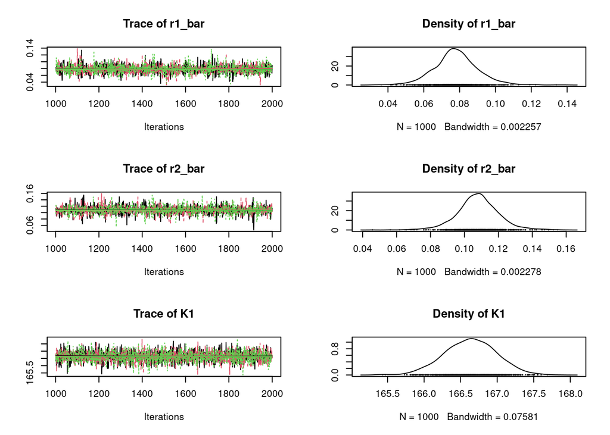

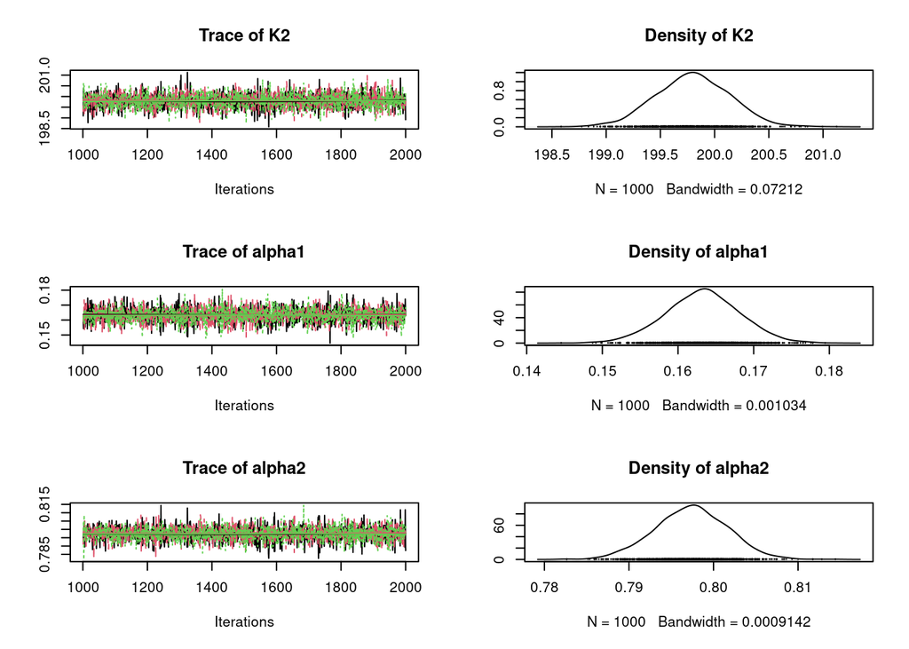

```r
samples=As.mcmc.list(fit)
params = c("r1_bar","r2_bar", "K1", "K2", "alpha1", "alpha2")
plot(samples[, params])
```

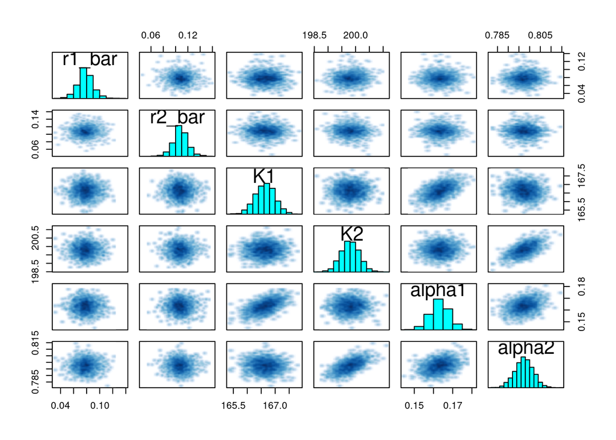

```r
pairs(fit, pars=params)
```

# V- posterior predictions

Let us first fit the predictions with the random effect:

```r
ode.model = function(t,N,p){
  r1 = p$r1
  r2 = p$r2
  K1 = p$K1
  K2 = p$K2
  alpha1 = p$alpha1
  alpha2 = p$alpha2
  dn1 = r1*N[1]*(1-(N[1]+alpha1*N[2])/K1)
  dn2 = r2*N[2]*(1-(alpha2*N[1]+N[2])/K2)
  return(list(c(dn1, dn2)))
}

posteriors = as.matrix(fit)
#
n_post = 200
times = seq(min(data$time), max(data$time), length.out = 200)
for (k in 1:n_post){
  par = posteriors[sample(1:nrow(posteriors), 1),]
  for (replicate in 1:m){
    ## coculture predictions
    sim = ode(c(par[paste0('n10sim[', replicate, ']')], par[paste0('n20sim[', replicate, ']')]),
            times, ode.model, list(r1 = par[paste0('r1[', replicate, ']')] , r2= par[paste0('r2[', replicate, ']')] , K1 = par['K1'], K2 = par['K2'], alpha1 = par['alpha1'], alpha2 = par['alpha2']))

    temp  = data.frame(time = sim[,1], n1 = sim[,2], n2 = sim[,3], id = k, replicate = replicate, species = 'coculture')

    ## n1 monoculture predictions
    sim = ode(c(par[paste0('n10sim_mono[', replicate, ']')], 0),
            times, ode.model, list(r1 = par[paste0('r1[', replicate, ']')] , r2= par[paste0('r2[', replicate, ']')] , K1 = par['K1'], K2 = par['K2'], alpha1 = par['alpha1'], alpha2 = par['alpha2']))

    temp  = rbind(temp, data.frame(time = sim[,1], n1 = sim[,2], n2 = sim[,3], id = k, replicate = replicate, species = 'n1'))

    ## n2 monoculture predictions
    sim = ode(c(0, par[paste0('n20sim_mono[', replicate, ']')]),
            times, ode.model, list(r1 = par[paste0('r1[', replicate, ']')] , r2= par[paste0('r2[', replicate, ']')] , K1 = par['K1'], K2 = par['K2'], alpha1 = par['alpha1'], alpha2 = par['alpha2']))

    temp  = rbind(temp, data.frame(time = sim[,1], n1 = sim[,2], n2 = sim[,3], id = k, replicate = replicate, species = 'n2'))

    if (k == 1 & replicate == 1){
      predictions = temp
    } else {
      predictions = rbind(predictions, temp)
    }
  }
}
```

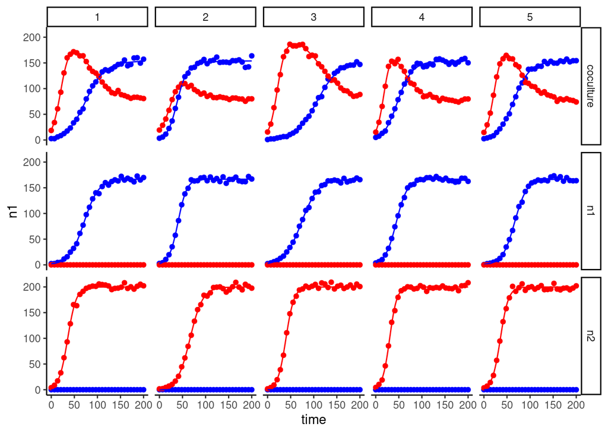

```r
ggplot(data) +
  geom_point(mapping = aes(x = time, y = n1), color = 'blue') +
  geom_point(mapping = aes(x = time, y = n2), color = 'red') +
  stat_summary(data = predictions, mapping = aes(x = time, y = n1),
               fun.min = function(x) quantile(x, 0.05),
               fun.max = function(x) quantile(x, 0.95),
               geom = 'ribbon', fill = 'blue', alpha = 0.2) +
  stat_summary(data = predictions, mapping = aes(x = time, y = n1),
               fun = median,
               geom = 'line', color = 'blue') +
  stat_summary(data = predictions, mapping = aes(x = time, y = n2),
               fun.min = function(x) quantile(x, 0.05),
               fun.max = function(x) quantile(x, 0.95),
               geom = 'ribbon', fill = 'red', alpha = 0.2) +
  stat_summary(data = predictions, mapping = aes(x = time, y = n2),
               fun = median,
               geom = 'line', color = 'red') +
  facet_grid(species~replicate) +
  theme_classic()
```

And with the estimated average (r1_bar and r2_bar):

```r
n_post = 200
times = seq(min(data$time), max(data$time), length.out = 200)
for (k in 1:n_post){
  par = posteriors[sample(1:nrow(posteriors), 1),]
  for (replicate in 1:m){
    ## coculture predictions
    sim = ode(c(par[paste0('n10sim[', replicate, ']')], par[paste0('n20sim[', replicate, ']')]),
            times, ode.model, list(r1 = par['r1_bar'] , r2= par['r2_bar'] , K1 = par['K1'], K2 = par['K2'], alpha1 = par['alpha1'], alpha2 = par['alpha2']))

    temp  = data.frame(time = sim[,1], n1 = sim[,2], n2 = sim[,3], id = k, replicate = replicate, species = 'coculture')

    ## n1 monoculture predictions
    sim = ode(c(par[paste0('n10sim_mono[', replicate, ']')], 0),
            times, ode.model, list(r1 = par['r1_bar'] , r2= par['r2_bar'] , K1 = par['K1'], K2 = par['K2'], alpha1 = par['alpha1'], alpha2 = par['alpha2']))

    temp  = rbind(temp, data.frame(time = sim[,1], n1 = sim[,2], n2 = sim[,3], id = k, replicate = replicate, species = 'n1'))

    ## n2 monoculture predictions
    sim = ode(c(0, par[paste0('n20sim_mono[', replicate, ']')]),
            times, ode.model, list(r1 = par['r1_bar'] , r2= par['r2_bar'] , K1 = par['K1'], K2 = par['K2'], alpha1 = par['alpha1'], alpha2 = par['alpha2']))

    temp  = rbind(temp, data.frame(time = sim[,1], n1 = sim[,2], n2 = sim[,3], id = k, replicate = replicate, species = 'n2'))

    if (k == 1 & replicate == 1){
      predictions_average = temp
    } else {
      predictions_average = rbind(predictions_average, temp)
    }
  }
}
```

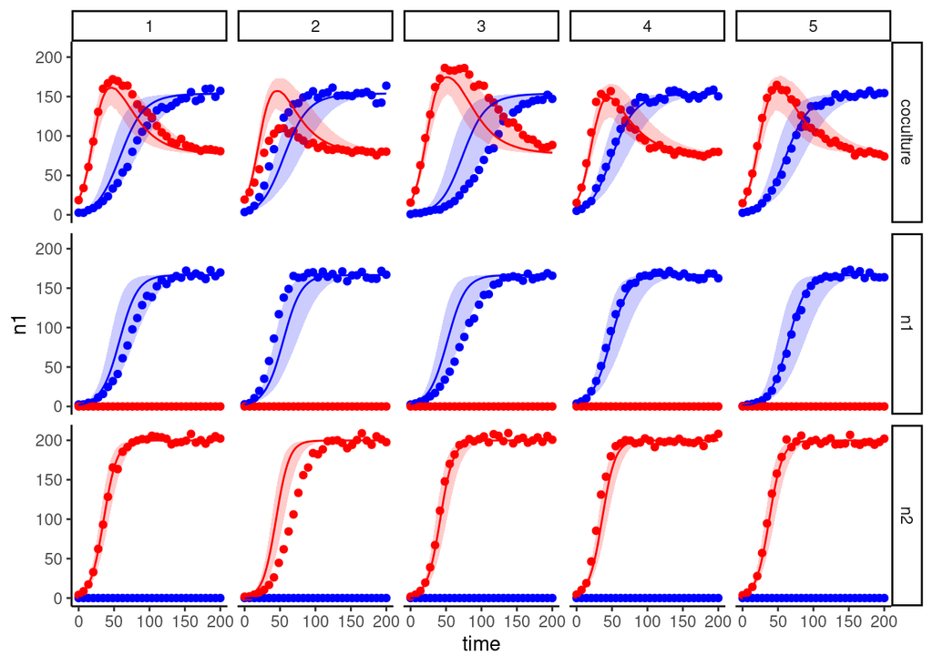

```r
ggplot(data) +
  geom_point(mapping = aes(x = time, y = n1), color = 'blue') +
  geom_point(mapping = aes(x = time, y = n2), color = 'red') +
  stat_summary(data = predictions_average, mapping = aes(x = time, y = n1),
               fun.min = function(x) quantile(x, 0.05),
               fun.max = function(x) quantile(x, 0.95),
               geom = 'ribbon', fill = 'blue', alpha = 0.2) +
  stat_summary(data = predictions_average, mapping = aes(x = time, y = n1),
               fun = median,
               geom = 'line', color = 'blue') +
  stat_summary(data = predictions_average, mapping = aes(x = time, y = n2),
               fun.min = function(x) quantile(x, 0.05),
               fun.max = function(x) quantile(x, 0.95),
               geom = 'ribbon', fill = 'red', alpha = 0.2) +
  stat_summary(data = predictions_average, mapping = aes(x = time, y = n2),
               fun = median,
               geom = 'line', color = 'red') +
  facet_grid(species~replicate) +
  theme_classic()
```